# Multivariate Data Analysis Project

Sara Vasques

Rita Pinto

Juan Pablo Martinez Aldana

2025-12-11

```r
# 2. Create folder if it doesn't exist
out_dir <- file.path("./plots")   # change base path if needed
```

# Abstract

Air pollution in urban environments is a significant public health concern. Some evidence indicates that air pollution exposure has way more consequences than the ones that we thought previously. In terms of adverse health impacts like the reduction in life expectancy, and hospital admissions, birth outcomes, and asthma. Nevertheless, these effects exist in both economically developing and developed countries [1].

Classical PCA can be expressed as a projection-based approach, since it’s a method that projects high-dimensional data into a lower-dimensional space by finding the principal components (PC) that best represent the original information. With this, we can do a dimensional reduction while preserving the essential structure of the data. [2]

Due to the reasons mentioned before, this project aims to analyze a dataset of 41 US cities to identify underlying patterns and relationships between pollution levels, climatic conditions, and demographic or industrial factors.

The study utilizes multivariate techniques, primarily **Principal Component Analysis (PCA)** and **Cluster Analysis**, to reduce the complexity of the data and group cities with similar profiles. The objective is to translate complex statistical relationships into clear, interpretable insights.

The dataset contains the following variables:

**so2**: Sulfur dioxide content of air in micrograms per cubic meter

**temp**: Average annual temperature in Fahrenheit

**manuf**: Number of manufacturing enterprises employing 20 or more workers

**pop**: Population size (1970 census) in thousands

**wind**: Average wind speed in miles per hour

**precip**: Average annual precipitation in inches

**days**: Average number of days with precipitation per year

# Preliminary analysis of the data

Before applying multivariate methods, a preliminary analysis is essential to understand the individual variables and their pairwise relationships.

```
##       city so2 temp manuf pop wind precip days
## 1  Phoenix  10 70.3   213 582  6.0   7.05   36
## 2 Little R  13 61.0    91 132  8.2  48.52  100
## 3 San Fran  12 56.7   453 716  8.7  20.66   67
## 4   Denver  17 51.9   454 515  9.0  12.95   86
## 5 Hartford  56 49.1   412 158  9.0  43.37  127
## 6 Wilmingt  36 54.0    80  80  9.0  40.25  114
```

```
## [1] 41  8
```

```
## 'data.frame':    41 obs. of  8 variables:
##  $ city  : chr  "Phoenix" "Little R" "San Fran" "Denver" ...
##  $ so2   : int  10 13 12 17 56 36 29 14 10 24 ...
##  $ temp  : num  70.3 61 56.7 51.9 49.1 54 57.3 68.4 75.5 61.5 ...
##  $ manuf : int  213 91 453 454 412 80 434 136 207 368 ...
##  $ pop   : int  582 132 716 515 158 80 757 529 335 497 ...
##  $ wind  : num  6 8.2 8.7 9 9 9 9.3 8.8 9 9.1 ...
##  $ precip: num  7.05 48.52 20.66 12.95 43.37 ...
##  $ days  : int  36 100 67 86 127 114 111 116 128 115 ...
```

## Numerical Data

```
##   so2 temp manuf pop wind precip days
## 1  10 70.3   213 582  6.0   7.05   36
## 2  13 61.0    91 132  8.2  48.52  100
## 3  12 56.7   453 716  8.7  20.66   67
## 4  17 51.9   454 515  9.0  12.95   86
## 5  56 49.1   412 158  9.0  43.37  127
## 6  36 54.0    80  80  9.0  40.25  114
```

## Descriptive Statistics

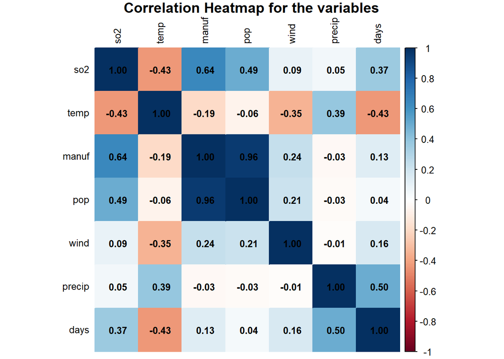

```r
#correlation heatmap of the numeric variables

# install.packages(c("corrplot", "reshape2"))
library(corrplot)
library(reshape2)
corr_matrix <- cor(data5_variables, use = "complete.obs")  # handles missing values

# Basic correlation heatmap
corrplot(corr_matrix, method = "color",
         addCoef.col = "black",   # show correlation coefficients
         tl.col = "black",        # axis labels color
         number.cex = 0.8,       # font size for coefficients
         tl.cex = 0.8,            # font size for labels
         title = "Correlation Heatmap for the variables",
         mar = c(0,0,1,0))
```

```r
# Calculate standard deviation for each variable.
library(dplyr)

data5_variables %>% summarise_if(is.numeric, sd)
```

```
##        so2     temp    manuf     pop     wind   precip     days
## 1 23.47227 7.227716 563.4739 579.113 1.428644 11.77155 26.50642
```

## Correlation Analysis + Correlation Matrix

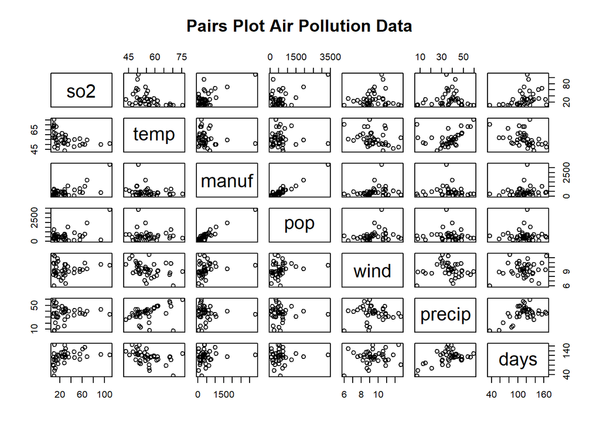

```r
# Visualize pairwise relationships between all variables.
pairs(data5_variables, main="Pairs Plot Air Pollution Data")
```

**CORRELATION MATRIX**

```r
# 1st) Calculate and display the correlation matrix.
cor_data5 <- cor(data5_variables)
cor_data5
```

```
##                so2        temp       manuf         pop        wind      precip
## so2     1.00000000 -0.43360020  0.64476873  0.49377958  0.09469045  0.05429434
## temp   -0.43360020  1.00000000 -0.19004216 -0.06267813 -0.34973963  0.38625342
## manuf   0.64476873 -0.19004216  1.00000000  0.95526935  0.23794683 -0.03241688
## pop     0.49377958 -0.06267813  0.95526935  1.00000000  0.21264375 -0.02611873
## wind    0.09469045 -0.34973963  0.23794683  0.21264375  1.00000000 -0.01299438
## precip  0.05429434  0.38625342 -0.03241688 -0.02611873 -0.01299438  1.00000000
## days    0.36956363 -0.43024212  0.13182930  0.04208319  0.16410559  0.49609671
##               days
## so2     0.36956363
## temp   -0.43024212
## manuf   0.13182930
## pop     0.04208319
## wind    0.16410559
## precip  0.49609671
## days    1.00000000
```

```r
library(GGally)
```

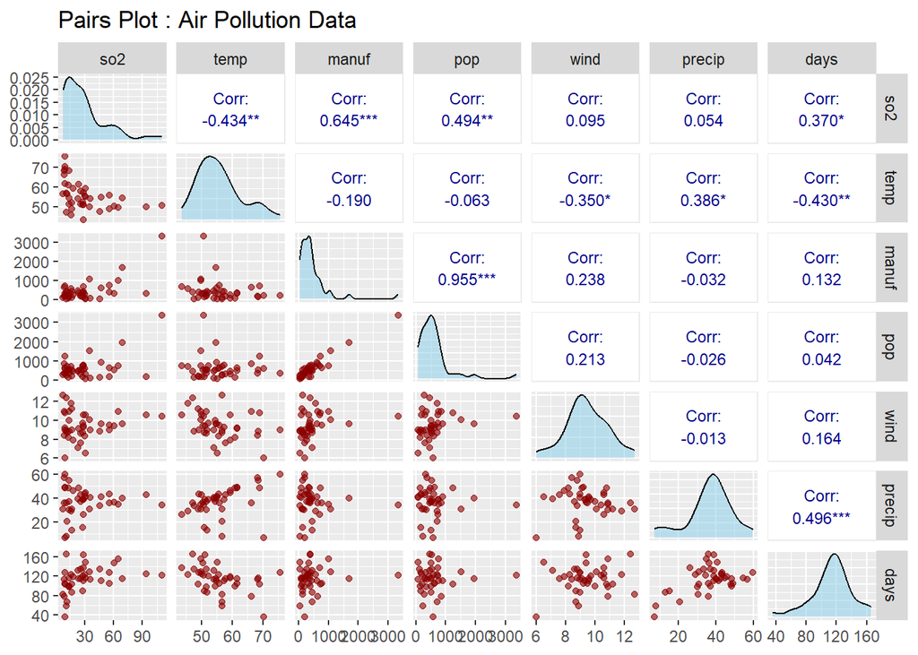

```r
p <- ggpairs(
  data5_variables,
  title = "Pairs Plot : Air Pollution Data",
  upper = list(continuous = wrap("cor", size = 3, color="darkblue")),
  lower = list(continuous = wrap("points", alpha = 0.6, size=1.5, color="darkred")),
  diag = list(continuous = wrap("densityDiag", alpha=0.5, fill="skyblue"))
)
p
```

```r
ggsave("plots/pairs_plot.png", plot = p, width = 10, height = 8, dpi = 300)
```

# Principal Component Analysis (PCA)

PCA will be used to reduce the dimensionality of the dataset. By creating a smaller set of uncorrelated components, we can simplify the data while retaining most of the original variance. We will use the *correlation matrix* (`scale = TRUE`) to account for the different units and scales of the original variables.

**EIGENVALUES AND EIGENVECTORS**

```r
## 2nd) Obtain eigenvectors and eigenvalues

eigen_data5 <- eigen(cor_data5)
eigen_data5
```

```
## eigen() decomposition
## $values
## [1] 2.72811968 1.51233485 1.39497299 0.89199129 0.34677866 0.10028759 0.02551493
##
## $vectors
##               [,1]        [,2]       [,3]        [,4]       [,5]        [,6]
## [1,]  0.4896988171 -0.08457563 -0.0143502  0.40421007  0.7303942 -0.18334573
## [2,] -0.3153706901  0.08863789 -0.6771362 -0.18522794  0.1624652 -0.61066107
## [3,]  0.5411687028  0.22588109 -0.2671591 -0.02627237 -0.1641011  0.04273352
## [4,]  0.4875881115  0.28200380 -0.3448380 -0.11340377 -0.3491048  0.08786327
## [5,]  0.2498749284 -0.05547149  0.3112655 -0.86190131  0.2682549 -0.15005378
## [6,]  0.0001873122 -0.62587937 -0.4920363 -0.18393719  0.1605988  0.55357384
## [7,]  0.2601790729 -0.67796741  0.1095789  0.10976070 -0.4399698 -0.50494668
##              [,7]
## [1,]  0.149529278
## [2,] -0.023664113
## [3,] -0.745180920
## [4,]  0.649125507
## [5,]  0.015765377
## [6,] -0.010315309
## [7,]  0.008217393
```

## Justification for Number of Components Retained

### Criteria 1 => Kaiser’s Criteria

*Analyzing the results*, we should retain the first 3 PCs because there are 3 eigenvalues that are >1 (Kaiser’s Criteria).

However, there are other criteria that we should take into consideration. Now we will perform PCA to see if 3 PCs explain the majority of the variance or not.

### Criteria 2 => PCA

```r
# 3rd) Perfom PCA
library(stats)
pca_results <- princomp(data5_variables, cor = TRUE)

print(summary(pca_results), loadings = TRUE)
```

```
## Importance of components:
##                           Comp.1    Comp.2    Comp.3    Comp.4     Comp.5
## Standard deviation     1.6517021 1.2297702 1.1810897 0.9444529 0.58887916
## Proportion of Variance 0.3897314 0.2160478 0.1992819 0.1274273 0.04953981
## Cumulative Proportion  0.3897314 0.6057792 0.8050611 0.9324884 0.98202821
##                           Comp.6      Comp.7
## Standard deviation     0.3166822 0.159733920
## Proportion of Variance 0.0143268 0.003644989
## Cumulative Proportion  0.9963550 1.000000000
##
## Loadings:
##        Comp.1 Comp.2 Comp.3 Comp.4 Comp.5 Comp.6 Comp.7
## so2     0.490                0.404  0.730  0.183  0.150
## temp   -0.315         0.677 -0.185  0.162  0.611
## manuf   0.541 -0.226  0.267        -0.164        -0.745
## pop     0.488 -0.282  0.345 -0.113 -0.349         0.649
## wind    0.250        -0.311 -0.862  0.268  0.150
## precip         0.626  0.492 -0.184  0.161 -0.554
## days    0.260  0.678 -0.110  0.110 -0.440  0.505
```

*Analyzing the results*, we have 81% of the variance explained with the first 3 PCs (viewed in the cumulative proportion). However, if we consider 4 PCs, we will have 93% of the variance explained.

Since this is not conclusive, we should do the third criteria.

### Criteria 3 => Scree Plot

Now we have all that we need to do is a *scree plot* to see where the elbow point might be:

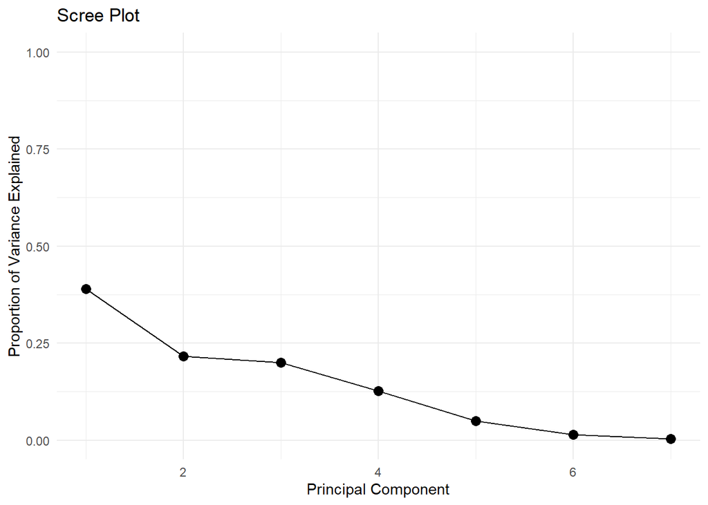

```r
library(ggplot2)

eigenvalues <- eigen_data5$values

scree_data <- data.frame(
  component = 1:length(eigenvalues),
  variance_explained = eigenvalues / sum(eigenvalues)
)
ggplot(scree_data, aes(x = component, y = variance_explained)) +
  geom_line() +
  geom_point(size=3) +
  ylim(0,1) +
  labs(title = "Scree Plot", x = "Principal Component", y = "Proportion of Variance Explained") +
  theme_minimal()
```

### Criteria 3 => Scree Plot Enhance with Kaizer criteria

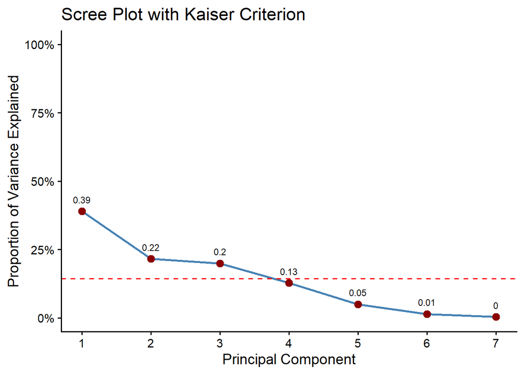

*Analyzing the results*, in this plot, the elbow point would be between PC2 and PC3. However, if we consider the other criterias we have applied before, it would be best to use 3 PCs, having approximately 81% of the variance explained.

**SO LET’S CONSIDER 3 PCs.**

Now, we need to see which are the variables that contribute more for the explanation of each principal component retained. We need to have a correlation matrix between the variables and the PCs (the loadings).

## Component Interpretation (Loadings)

```r
# Correlation between original variables and the PCs (loadings)

component_matrix <- cor(data5_variables,pca_results$scores)
component_matrix
```

```
##               Comp.1      Comp.2      Comp.3      Comp.4      Comp.5
## so2     0.8088365434  0.10400859  0.01694887  0.38175738  0.43011391
## temp   -0.5208984175 -0.10900423  0.79975860 -0.17493906  0.09567234
## manuf   0.8938494595 -0.27778184  0.31553891 -0.02481301 -0.09663572
## pop     0.8053502866 -0.34679989  0.40728458 -0.10710452 -0.20558056
## wind    0.4127189331  0.06821718 -0.36763244 -0.81402520  0.15796972
## precip  0.0003093839  0.76968782  0.58113903 -0.17372001  0.09457328
## days    0.4297383099  0.83374415 -0.12942257  0.10366381 -0.25908903
##             Comp.6       Comp.7
## so2     0.05806232  0.023884898
## temp    0.19338547 -0.003779961
## manuf  -0.01353294 -0.119030670
## pop    -0.02782473  0.103687362
## wind    0.04751936  0.002518265
## precip -0.17530696 -0.001647705
## days    0.15990761  0.001312596
```

We only need to look into the the 3 first PCs, since we determined we are going to use the first three.

To verify that we made the right decisions:

# Tables to summarize the loadings

```r
library(gridExtra)
```

```r
library(grid)

# Create table of loadings for the 3 PCs
loadings_table <- data.frame(
  Variable = c("so2", "temp", "manuf", "pop", "wind", "precip", "days"),
  PC1 = c(0.8088365434, -0.5208984175, 0.8938494595, 0.8053502866, 0.4127189331, 0.0003093839, 0.4297383099),
  PC2 = c(0.10400859, -0.10900423, -0.27778184, -0.34679989, 0.06821718, 0.76968782, 0.83374415),
  PC3 = c(0.01694887, 0.79975860, 0.31553891, 0.40728458, -0.36763244, 0.58113903, -0.12942257)
)

# Create a visual table.
loadings_plot <- tableGrob(
  loadings_table,
  rows = NULL,
  theme = ttheme_default(
    core = list(fg_params = list(hjust = 0.5, x = 0.5)),
    colhead = list(fg_params = list(fontface = "bold", hjust = 0.5))
  )
)

# # Export as png
if(!dir.exists("./plots")) dir.create("./plots")
png("./plots/pca_loadings_table.png", width = 900, height = 400)
grid.draw(loadings_plot)
# dev.off()
```

# Style 2 of table

```r
library(knitr)

library(kableExtra)
loadings_table <- data.frame(
  Variable = c("so2", "temp", "manuf", "pop", "wind", "precip", "days"),
  PC1 = c(0.8088365434, -0.5208984175, 0.8938494595, 0.8053502866, 0.4127189331, 0.0003093839, 0.4297383099),
  PC2 = c(0.10400859, -0.10900423, -0.27778184, -0.34679989, 0.06821718, 0.76968782, 0.83374415),
  PC3 = c(0.01694887, 0.79975860, 0.31553891, 0.40728458, -0.36763244, 0.58113903, -0.12942257)
)

kable(loadings_table, format = "html", digits = 4, align = "c",
      col.names = c("Variable", "PC1", "PC2", "PC3")) %>%
  kable_styling(full_width = FALSE, position = "center", bootstrap_options = c("striped", "hover"))
```

| Variable | PC1 | PC2 | PC3 |
| --- | --- | --- | --- |
| so2 | 0.8088 | 0.1040 | 0.0169 |
| temp | -0.5209 | -0.1090 | 0.7998 |
| manuf | 0.8938 | -0.2778 | 0.3155 |
| pop | 0.8054 | -0.3468 | 0.4073 |
| wind | 0.4127 | 0.0682 | -0.3676 |
| precip | 0.0003 | 0.7697 | 0.5811 |
| days | 0.4297 | 0.8337 | -0.1294 |

Let’s prove that with:

```r
# Apply the rule for the 1st PC
# lambda1 / p

sqrt(eigen_data5$values[1]/8)
```

```
## [1] 0.5839649
```

We considered everything above this value for PC1.

```r
# Apply the rule for the 2nd PC
# lambda1 / p

sqrt(eigen_data5$values[2]/8)
```

```
## [1] 0.4347894
```

We considered everything above this value for PC2.

```r
# Apply the rule for the 3rd PC
# lambda1 / p

sqrt(eigen_data5$values[3]/8)
```

```
## [1] 0.4175783
```

We considered everything above this value for PC3.

## Visualization of the Data

```r
######Scores
#Put the scores in their own variable to use
scores <- as.data.frame(pca_results$scores)

#City names
scores$city <- data5$city
```

The next 3 graphics are on the first 3 PCs:

# Biplots

## PC1 vs PC2

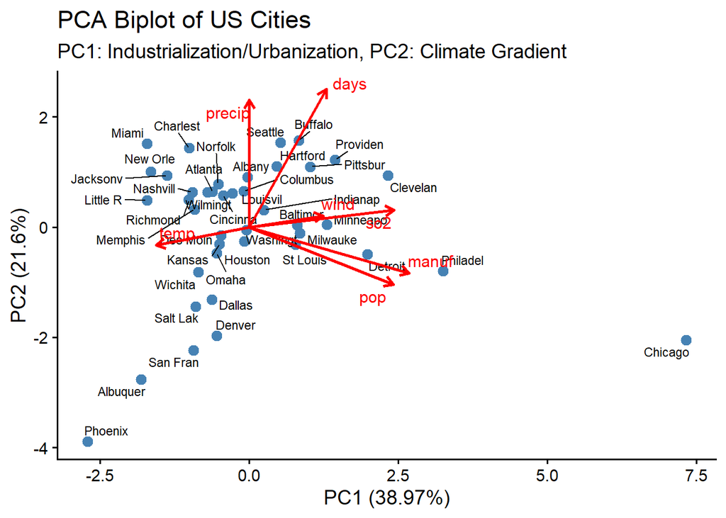

```
## Aesthetic mapping:
```

```
## Aesthetic mapping:
```

## PC2 vs PC3

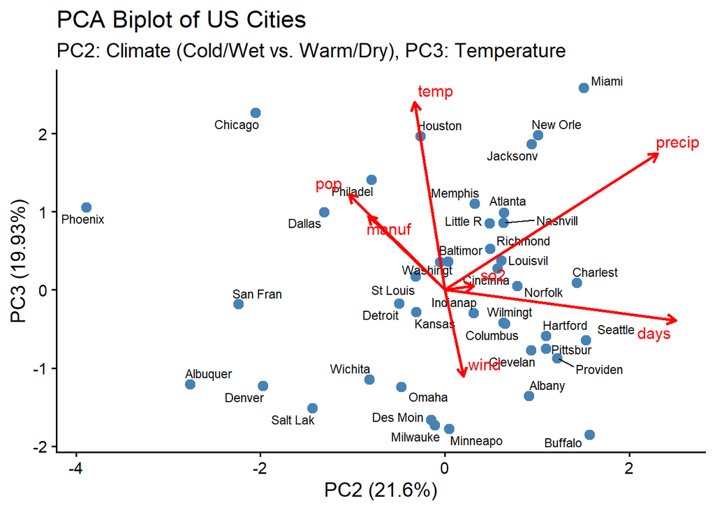

```
## Aesthetic mapping:
```

```
## Aesthetic mapping:
```

## PC1 vs PC3

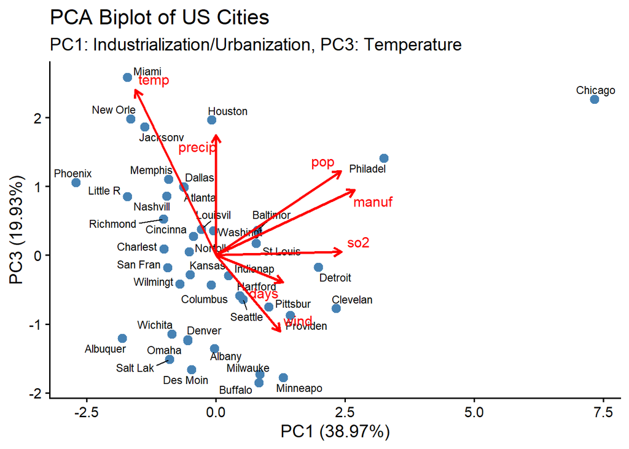

# 3D plots

```r
library(plotly)
data5_2 <- prcomp(data5_variables, scale. = TRUE)

raw_standardized_data <- as.data.frame(scale(data5_variables))

pca_scores_data <- pca_scores_data <- as.data.frame(pca_results$scores[, 1:3])

pca_scores <- as.data.frame(data5_2$x)

# 1. Extract the scores and city names from our existing PCA results
scores_df <- as.data.frame(pca_results$scores)
scores_df$city <- data5$city

# 2. Get the proportion of variance explained for axis labels
# This comes from the summary of our pca_results object
pca_summary <- summary(pca_results)
variance_explained <- pca_summary$sdev^2 / sum(pca_summary$sdev^2)

pc1_label <- paste0("PC1 (", round(variance_explained[1] * 100, 1), "%)")
pc2_label <- paste0("PC2 (", round(variance_explained[2] * 100, 1), "%)")
pc3_label <- paste0("PC3 (", round(variance_explained[3] * 100, 1), "%)")

# 3. Create the interactive 3D plot
plot_ly(data = scores_df,
        x = ~Comp.1, y = ~Comp.2, z = ~Comp.3,
        text = ~city, # Use city names for hover text
        type = 'scatter3d',
        mode = 'markers',
        marker = list(size = 5, color = ~Comp.1, colorscale = 'Viridis', showscale = TRUE, colorbar = list(title = pc1_label))) %>%
  layout(
    title = "Interactive 3D PCA Scatter Plot of US Cities (Improved)",
    scene = list(
      xaxis = list(title = pc1_label),
      yaxis = list(title = pc2_label),
      zaxis = list(title = pc3_label)
    )
  )
```

[interactive chart not shown]

# Cluster Analysis

Now we will do a completely different analysis and group similar cities using *hierarchical clustering*. We will perform this in two forms, with the original data and with the PCA scores, since it’s normal to use the latter in some types of analyses.

```r
#Load the libraries needed
library(tidyverse) #data manipulation
library(cluster) #clustering algorithms
library(factoextra) #clustering visualization
library(dendextend) #for comparing two dendograms
library(laGP) #squared Euclidean distance
library(metan) #clustering algorithms
library(tidygeocoder) # for geocoding
```

```r
library(maps) # for map data
```

## Cluster Analysis with the Original Data

To perform and obtain the *dendograms* we need to determine the distances (to cluster the groups).

[output not shown]

[output cut: 191 more lines]

```
## 27
## 28
## 29
## 30
## 31
## 32
## 33
## 34
## 35
## 36
## 37  3.2377652
## 38  2.8159721  2.1361914
## 39  3.5825373  2.4351812  2.4998917
## 40  3.5309514  3.2102914  1.6061419  2.4176981
## 41  3.1634873  2.7723954  3.7408457  2.6416464  4.4626474
```

### SINGLE LINKAGE

```r
hc1_s <- agnes(dist_data5, method = "single")
hc1_s$merge
```

```
##       [,1] [,2]
##  [1,]   -8  -16
##  [2,]  -13  -22
##  [3,]  -33  -38
##  [4,]  -10  -32
##  [5,]   -7  -12
##  [6,]  -17  -21
##  [7,]  -15    3
##  [8,]    7  -28
##  [9,]    4    8
## [10,]    5    6
## [11,]   -4  -36
## [12,]   10    9
## [13,]   -2   12
## [14,]    2  -20
```

[output cut: 26 more lines]

```r
hc1_s$order
```

```
##  [1]  1  2  7 12 17 21 10 32 15 33 38 28 26 13 22 20  6  8 16  9 39 40 37  5 24
## [26] 30 19 41 14 27 18 25 34 35 31  3  4 36 23 29 11
```

#### AC value.

```r
hc1_s$ac
```

```
## [1] 0.7033724
```

#### Cophenetic Coefficient.

```r
#Cophenetic Coefficient
clust_single_s <- hclust(dist_data5, method="single")

#Cophenetic matrix (delta matrix - obtained based on the dendogram)
coph_1_s <- cophenetic(clust_single_s)

#Cophenetic coefficient
cor(dist_data5, coph_1_s)
```

```
## [1] 0.8533611
```

#### Dendogram

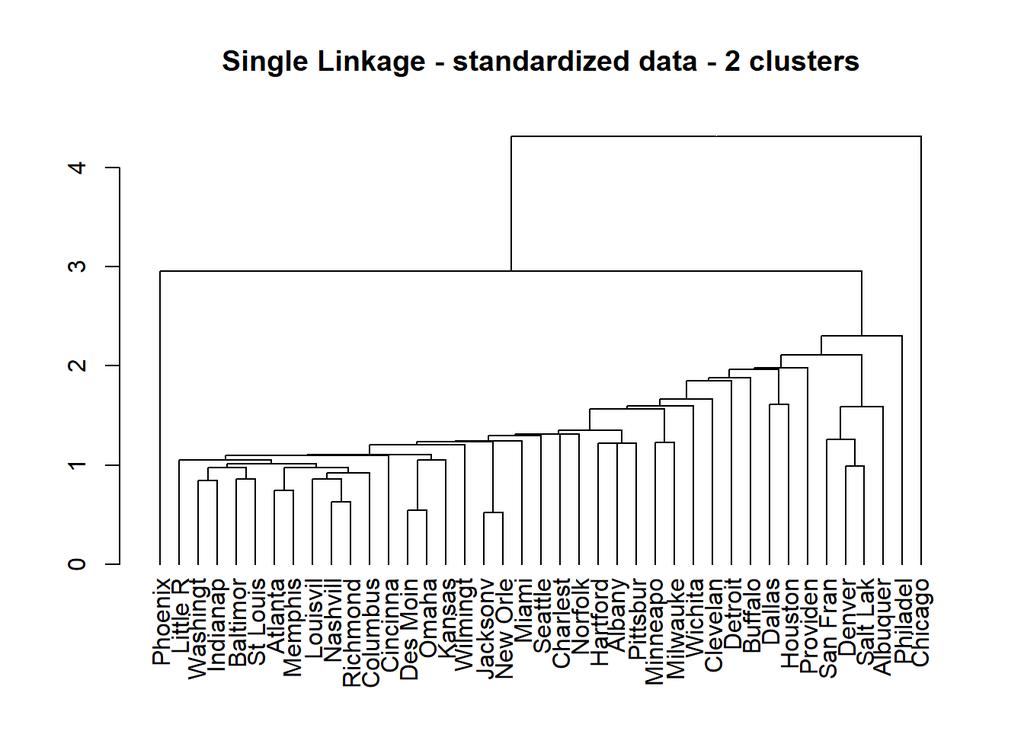

```r
#Dendrogram
dend1_s <- as.dendrogram(hc1_s)
#labels(dend1_s) <- data5$city
order_in_dend <- order.dendrogram(dend1_s)
labels(dend1_s) <- data5$city[order_in_dend]
plot(dend1_s, main = "Single Linkage - standardized data - 2 clusters")
```

### COMPLETE LINKAGE

```r
hc2_s <- agnes(dist_data5, method = "complete")
hc2_s$merge
```

```
##       [,1] [,2]
##  [1,]   -8  -16
##  [2,]  -13  -22
##  [3,]  -33  -38
##  [4,]  -10  -32
##  [5,]   -7  -12
##  [6,]  -17  -21
##  [7,]  -15    3
##  [8,]   -4  -36
##  [9,]    5  -20
## [10,]  -26  -28
## [11,]   -5  -24
## [12,]  -19  -41
## [13,]    1   -9
## [14,]   -2    4
```

[output cut: 26 more lines]

```r
hc2_s$order
```

```
##  [1]  1  3 23  4 36 13 22 14  2 10 32  8 16  9 34 35  5 24 30 39  6 37  7 12 20
## [26] 17 21 15 33 38 26 28 40 31 19 41 25 18 27 29 11
```

#### AC Value

```r
hc2_s$ac
```

```
## [1] 0.8376211
```

#### Cophenetic Coefficient

```r
#Cophenetic Coefficient
clust_complete_s <- hclust(dist_data5, method="complete")

#Cophenetic matrix (delta matrix - obtained based on the dendogram)
coph_2_s <- cophenetic(clust_complete_s)

#Cophenetic coefficient
cor(dist_data5, coph_2_s)
```

```
## [1] 0.6873652
```

It’s a smaller value than the *Single Linkage* one.

#### Dendrogram

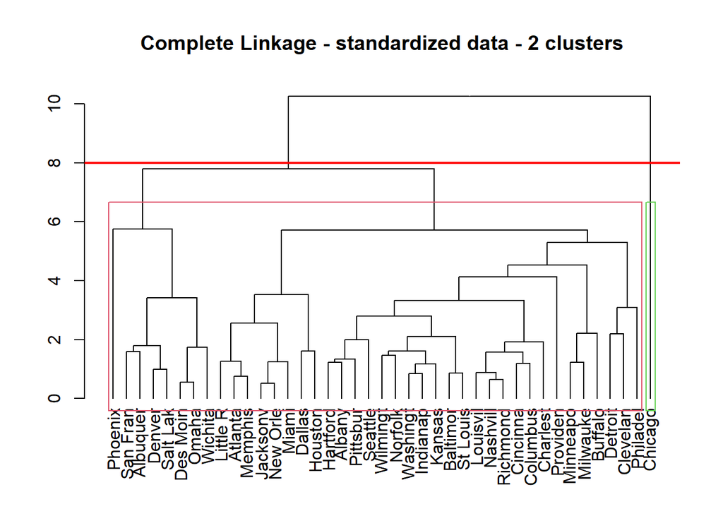

```r
#Dendrogram
dend2_s <- as.dendrogram(hc2_s)
#labels(dend1_s) <- data5$city
order_in_dend2 <- order.dendrogram(dend2_s)
labels(dend2_s) <- data5$city[order_in_dend2]
plot(dend2_s, main = "Complete Linkage - standardized data - 2 clusters")
abline(h = 8, col = "red", lwd = 2)
rect.hclust(hc2_s, k=2, border = 2:4)
```

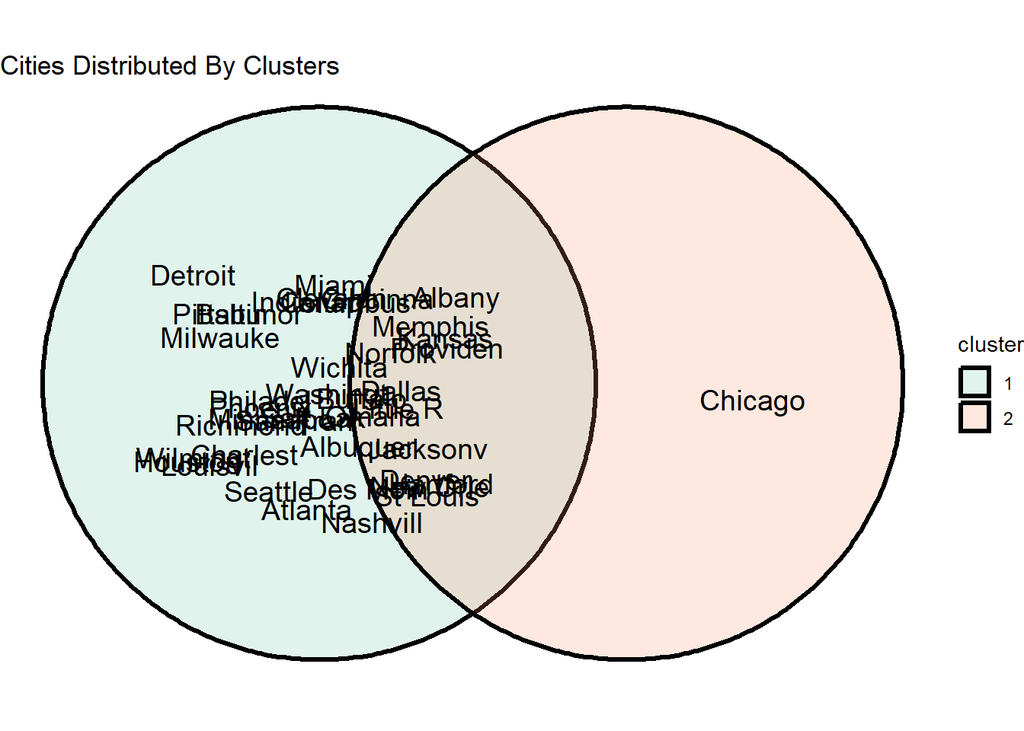

```r
library(ggplot2)
library(dplyr)
library(ggforce)
k <- 2
clusters <- cutree(hc2_s, k = k)

df <- data.frame(
  city = data5$city,
  cluster = factor(clusters)
)

circles <- data.frame(
  cluster = factor(c(1,2)),
  x0 = c(-1, 1),
  y0 = c(0, 0),
  r = c(1.8, 1.8)
)

set.seed(123)
df <- df %>%
  left_join(circles, by = "cluster") %>%
  rowwise() %>%
  mutate(
    x = x0 + runif(1, -0.9, 0.9),
    y = y0 + runif(1, -0.9, 0.9)
  )

ggplot() +
  geom_circle(data = circles,
              aes(x0 = x0, y0 = y0, r = r, fill = cluster),
              alpha = 0.2, color = "black", linewidth = 1.2) +
  geom_text(data = df, aes(x = x, y = y, label = city), size = 5) +
  coord_fixed() +
  theme_void() +
  scale_fill_manual(values = c("#66c2a5", "#fc8d62")) +
  ggtitle("Cities Distributed By Clusters")
```

### WARD LINKAGE

```r
hc3_s <- agnes(dist_data5, method = "ward")
hc3_s$merge
```

```
##       [,1] [,2]
##  [1,]   -8  -16
##  [2,]  -13  -22
##  [3,]  -33  -38
##  [4,]  -10  -32
##  [5,]   -7  -12
##  [6,]  -17  -21
##  [7,]  -15  -28
##  [8,]   -4  -36
##  [9,]    7  -26
## [10,]   -5  -24
## [11,]    5  -20
## [12,]  -19  -41
## [13,]   -2    3
## [14,]   10  -30
```

[output cut: 26 more lines]

```r
hc3_s$order
```

```
##  [1]  1  3 23  4 36  2 33 38 10 32 15 28 26 40  6 37  7 12 20 17 21  8 16  9 34
## [26] 35  5 24 30 39 31 18 27 29 13 22 14 19 41 25 11
```

#### AC ward

```r
hc3_s$ac
```

```
## [1] 0.8552635
```

The AC value is high.

#### Cophenetic Coefficient

```r
#Cophenetic Coefficient
clust_ward_s <- hclust(dist_data5, method="ward")
```

```
## The "ward" method has been renamed to "ward.D"; note new "ward.D2"
```

```r
#Cophenetic matrix (delta matrix - obtained based on the dendogram)
coph_3_s <- cophenetic(clust_ward_s)

#Cophenetic coefficient
cor(dist_data5, coph_3_s)
```

```
## [1] 0.4697547
```

#### Dendrogram

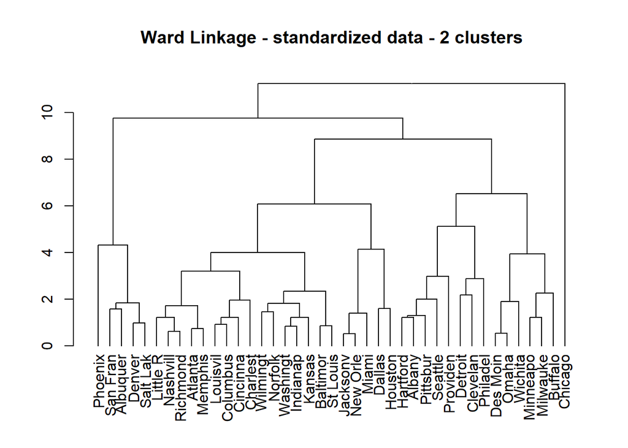

```r
dend3_s <- as.dendrogram(hc3_s)
#labels(dend1_s) <- data5$city
order_in_dend3 <- order.dendrogram(dend3_s)
labels(dend3_s) <- data5$city[order_in_dend3]
plot(dend3_s, main = "Ward Linkage - standardized data - 2 clusters")
```

## Cluster Analysis with the PCA Data

Add cities names´ to the pca_scores table

```r
identical(rownames(pca_scores), rownames(data5))
```

```
## [1] TRUE
```

```r
pca_scores2 <- cbind(city = data5$city, pca_scores)
#Considering 3 principal components for the PCA data :
pca_results$sdev
```

```
##    Comp.1    Comp.2    Comp.3    Comp.4    Comp.5    Comp.6    Comp.7
## 1.6517021 1.2297702 1.1810897 0.9444529 0.5888792 0.3166822 0.1597339
```

```r
pca_results$sdev[1:3]
```

```
##   Comp.1   Comp.2   Comp.3
## 1.651702 1.229770 1.181090
```

```r
#In order to perform and obtain the dendograms, we need to determine the distances
#(to cluster the groups).

pca_cluster <- pca_scores[,1:3] ; pca_cluster
```

```
##            PC1         PC2         PC3
## 1  -2.68264965 -3.84368955  1.04536813
## 2  -1.69666795  0.47650053  0.83961298
## 3  -0.92744347 -2.20979453 -0.18149322
## 4  -0.54311446 -1.94774644 -1.21352047
## 5   0.45472289  1.08386981 -0.58246788
## 6  -0.68852272  0.62439221 -0.41615954
## 7  -0.04555952 -0.05027326  0.34988543
## 8  -1.35912964  0.92688238  1.84306708
## 9  -1.69467532  1.48949101  2.55354056
## 10 -0.61099829  0.63025982  0.97623533
## 11  7.23097079 -2.02725781  2.23562114
## 12  0.24048944  0.30539249 -0.29507787
## 13 -0.46515732 -0.14701111 -1.63953441
## 14 -0.84415913 -0.81131118 -1.12909377
```

[output cut: 27 more lines]

```r
pca_cluster2 <- pca_scores2[,1:4] ; pca_cluster2 #usar com labels das cidades
```

```
##        city         PC1         PC2         PC3
## 1   Phoenix -2.68264965 -3.84368955  1.04536813
## 2  Little R -1.69666795  0.47650053  0.83961298
## 3  San Fran -0.92744347 -2.20979453 -0.18149322
## 4    Denver -0.54311446 -1.94774644 -1.21352047
## 5  Hartford  0.45472289  1.08386981 -0.58246788
## 6  Wilmingt -0.68852272  0.62439221 -0.41615954
## 7  Washingt -0.04555952 -0.05027326  0.34988543
## 8  Jacksonv -1.35912964  0.92688238  1.84306708
## 9     Miami -1.69467532  1.48949101  2.55354056
## 10  Atlanta -0.61099829  0.63025982  0.97623533
## 11  Chicago  7.23097079 -2.02725781  2.23562114
## 12 Indianap  0.24048944  0.30539249 -0.29507787
## 13 Des Moin -0.46515732 -0.14701111 -1.63953441
## 14  Wichita -0.84415913 -0.81131118 -1.12909377
```

[output cut: 27 more lines]

```r
dist_pca <- dist(pca_cluster,method="euclidean")
dist_pca
```

```
##             1          2          3          4          5          6          7
## 2   4.4360498
## 3   2.6936129  2.9749866
## 4   3.6434584  3.3797953  1.1320151
## 5   6.0641403  2.6494705  3.5943552  3.2533988
## 6   5.1065017  1.6171560  2.8539036  2.6968176  1.2432975
## 7   4.6720389  1.8009672  2.3924077  2.5084265  1.5510789  1.2063996
## 8   5.0146172  1.1505199  3.7581830  4.2745876  3.0328083  2.3759880  2.2158274
## 9   5.6296974  1.9909047  4.6640935  5.2279482  3.8234788  3.2526693  3.1538156
## 10  4.9307952  1.1049824  3.0832421  3.3831575  1.9419267  1.3945637  1.0840482
## 11 10.1486943  9.3765867  8.5109039  8.5052514  7.9710900  8.7625091  7.7725389
## 12  5.2494209  2.2515284  2.7754521  2.5562095  0.8570390  0.9896894  0.7901264
## 13  5.0785239  2.8375266  2.5680086  1.8520834  1.8651105  1.4634211  2.0354881
## 14  4.1597657  2.5022063  1.6913423  1.1786606  2.3616954  1.6105099  1.8450798
## 15  5.0984721  1.4949372  2.9387876  3.0144907  1.2971759  0.8852157  0.6961724
## 16  5.0340827  1.2346397  3.9176973  4.4621805  3.2908800  2.5828907  2.4909194
## 17  5.2512355  2.5716642  2.8779309  2.8608333  1.4499243  1.7716977  0.8407885
## 18  5.8561589  3.9151626  3.3619413  3.0795816  2.2158567  2.8838992  2.1185296
## 19  6.2214337  3.9753989  3.5291888  2.7574499  1.7726083  2.4530902  2.4924782
## 20  4.3646979  1.8195477  1.9538662  1.8894183  1.7107193  0.9619491  0.8123694
## 21  5.0146718  2.6730093  2.5697879  2.5134121  1.6176344  1.8293840  0.8735145
## 22  4.5993054  2.5470337  2.0691736  1.4821954  1.9511714  1.3656588  1.7031960
## 23  2.6525163  3.7966442  1.4292603  1.4756315  4.4689600  3.6156586  3.5515884
## 24  5.9313542  2.7710583  3.4345512  2.8943943  0.9173449  1.1622952  1.9351636
## 25  7.0435411  3.8215224  4.4607920  3.8031309  1.3811432  2.2639440  2.8392018
## 26  5.0095558  1.3883951  2.8539479  2.9191113  1.3353859  0.7322977  0.7325191
## 27  7.1272245  4.3248665  4.5335035  4.0631165  1.8551487  3.0180862  2.7696856
## 28  5.3847811  2.0471780  2.9826792  2.7458158  0.7218705  0.5930958  1.0420261
## 29  6.6473143  5.0981498  4.6492684  4.7132343  3.8724080  4.5240272  3.4976361
## 30  6.4112224  3.1934532  3.8614475  3.4381346  0.5784277  1.7898916  1.8949298
## 31  6.7791938  3.6245127  4.1993110  3.7307241  1.0119266  2.2317748  2.2783329
## 32  4.5230461  0.8395996  2.8290160  3.2512193  2.2905996  1.5523904  1.1962439
## 33  4.8000662  0.7658574  3.0182930  3.3237525  2.0545730  1.2916980  1.2323337
## 34  3.2768127  2.0770357  1.5136602  2.2954928  3.0469256  2.3783461  1.5129794
## 35  4.5141877  2.0834110  3.0010976  3.6053395  2.9086088  2.5868778  1.6039401
## 36  3.9440341  3.1178422  1.5344305  0.6896963  2.9860506  2.3228685  2.4499740
## 37  5.1955259  1.4505146  3.0194389  2.9992818  1.2000704  0.5174023  0.9951810
## 38  4.6725342  0.7661233  2.7840379  3.0202217  1.9213268  0.9953723  1.1076667
## 39  6.4627703  2.8571973  4.0190922  3.6649886  0.4364307  1.5152770  1.9322330
## 40  5.6016025  1.3867601  3.6340129  3.6342325  1.6363253  0.9883006  1.7659579
```

[output cut: 191 more lines]

```
## 27
## 28
## 29
## 30
## 31
## 32
## 33
## 34
## 35
## 36
## 37  2.7100938
## 38  2.7763381  0.7334885
## 39  3.3656340  1.4462419  2.1688774
## 40  3.2519400  0.8028877  1.0226889  1.6875224
## 41  2.1808440  2.3894716  2.9501593  1.9689507  2.9901517
```

### SINGLE LINKAGE

```r
#hierarchical clustering (aglommerative) using Single Linkage
hcpca1 <- agnes(dist_pca,method="single") #agnes Computes agglomerative hierarchical clustering of the dataset.
hcpca1$merge
```

```
##       [,1] [,2]
##  [1,]  -15  -26
##  [2,]   -8  -16
##  [3,]    1  -37
##  [4,]  -10  -33
##  [5,]    4  -38
##  [6,]    5  -32
##  [7,]  -17  -21
##  [8,]   -5  -39
##  [9,]  -30  -31
## [10,]  -14  -22
## [11,]  -19  -41
## [12,]  -12  -28
## [13,]   -6    3
## [14,]  -13   10
```

[output cut: 26 more lines]

```r
#Visualize the order in which the objects, clustered, appear in the dendrogram.
hcpca1$order
```

```
##  [1]  1  2  5 39 30 31  6 15 26 37 12 28 10 33 38 32  7 40 20 17 21 24 27  4 36
## [26] 13 14 22  8 16  9  3 25 18 19 41 35 23 34 29 11
```

#### AC

```r
hcpca1$ac
```

```
## [1] 0.8118718
```

#### Cophenetic single

```r
clust_pca <- clustering(pca_cluster,distmethod = "euclidean",clustmethod = "single")
clust_pca$cophenetic
```

```
## [1] 0.8529945
```

#### Dendogram

```r
dend1_pca <- as.dendrogram(hcpca1)
order_in_dend <- order.dendrogram(dend1_pca)
labels(dend1_pca) <- data5$city[order_in_dend]
dend1_pca
```

```
## 'dendrogram' with 2 branches and 41 members total, at height 4.290389
```

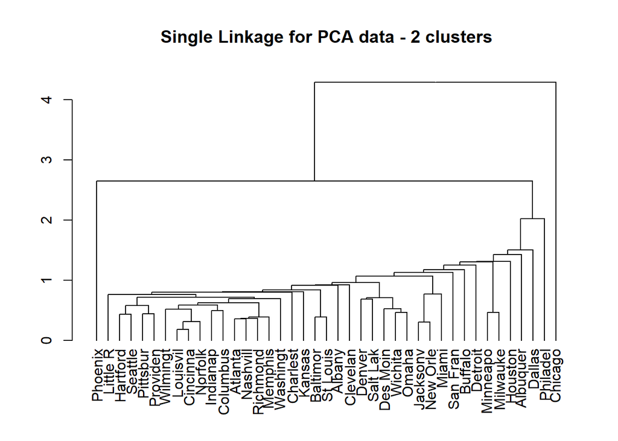

```r
plot(dend1_pca,main="Single Linkage for PCA data - 2 clusters")
```

### COMPLETE LINKAGE

```r
hcpca2 <- agnes(pca_cluster,method="complete")
hcpca2$merge
```

```
##       [,1] [,2]
##  [1,]  -15  -26
##  [2,]   -8  -16
##  [3,]  -10  -33
##  [4,]  -17  -21
##  [5,]    1  -37
##  [6,]   -5  -39
##  [7,]  -30  -31
##  [8,]    3  -32
##  [9,]  -14  -22
## [10,]  -19  -41
## [11,]  -12  -28
## [12,]    8  -38
## [13,]   -4  -36
## [14,]   -7  -20
```

[output cut: 26 more lines]

```r
hcpca2$order
```

```
##  [1]  1  3 23  4 36  2 10 33 32 38 40  8 16  9 34 35  5 39 30 31 24 25 19 41 17
## [26] 21 18 27  6 15 26 37 12 28  7 20 13 14 22 11 29
```

#### AC complete

```r
hcpca2$ac
```

```
## [1] 0.9007324
```

#### Cophenetic Coefficient

```r
clust_pca2 <- clustering(pca_cluster,distmethod = "euclidean",clustmethod = "complete")
clust_pca2$cophenetic
```

```
## [1] 0.7569114
```

#### Dendrogram

```r
dend2_pca <- as.dendrogram(hcpca2)
order_in_dend <- order.dendrogram(dend2_pca)
labels(dend2_pca) <- data5$city[order_in_dend]
dend2_pca
```

```
## 'dendrogram' with 2 branches and 41 members total, at height 10.14869
```

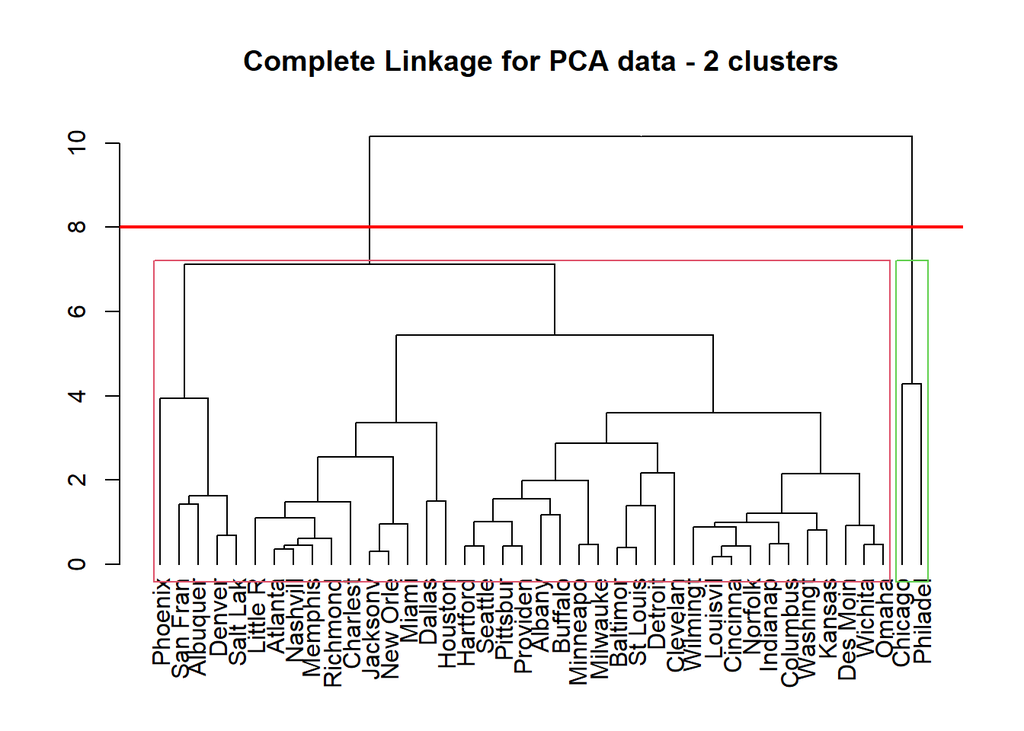

```r
plot(dend2_pca,main="Complete Linkage for PCA data - 2 clusters")
rect.hclust(hcpca2,k=2,border=2:4)
abline(h = 8, col = "red", lwd = 2)
```

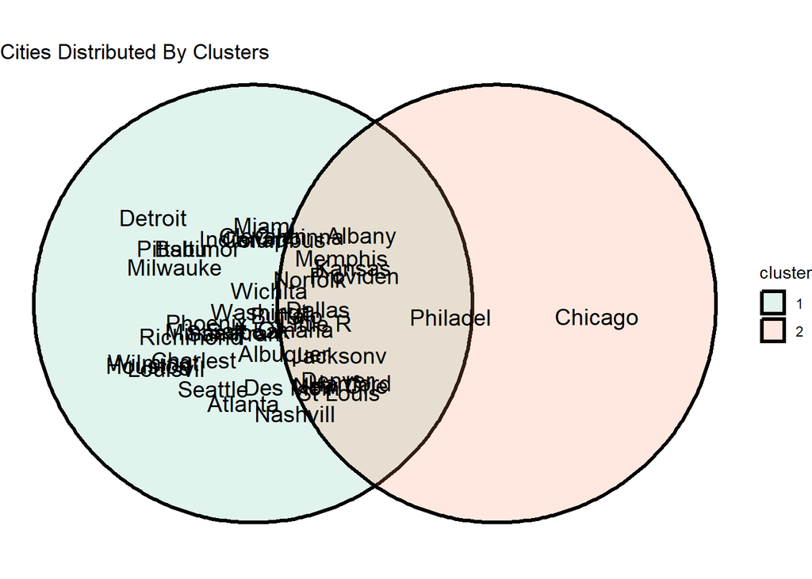

```r
library(ggplot2)
library(dplyr)
library(ggforce)

k <- 2
clusters <- cutree(hcpca2, k = k)

df <- data.frame(
  city = data5$city,
  cluster = factor(clusters)
)

circles <- data.frame(
  cluster = factor(c(1,2)),
  x0 = c(-1, 1),
  y0 = c(0, 0),
  r = c(1.8, 1.8)
)

set.seed(123)
df <- df %>%
  left_join(circles, by = "cluster") %>%
  rowwise() %>%
  mutate(
    x = x0 + runif(1, -0.9, 0.9),
    y = y0 + runif(1, -0.9, 0.9)
  )

ggplot() +
  geom_circle(data = circles,
              aes(x0 = x0, y0 = y0, r = r, fill = cluster),
              alpha = 0.2, color = "black", linewidth = 1.2) +
  geom_text(data = df, aes(x = x, y = y, label = city), size = 5) +
  coord_fixed() +
  theme_void() +
  scale_fill_manual(values = c("#66c2a5", "#fc8d62")) +
  ggtitle("Cities Distributed By Clusters")
```